# Visualising the Global Attitudes Spring 2022 Survey

## Preparing the Data

To analyze the attitudes of Singaporeans towards both the US and China, data from the Global Attitudes Spring 2022 survey conducted by Pew Research Center was loaded into R using the foreign package.

```r
#convert df to dataframe
df<- as.data.frame(df)

# Explore data set

head(df)
```

|  | survey | country | weight | id | econ_sit | children_betteroff2 | satisfied_democracy | tradition_change | fav_us | fav_china | fav_eu | fav_un | fav_nato | fav_russia | partyfav_australia_labour | partyfav_australia_liberal | partyfav_australia_greens | partyfav_australia_onenation | partyfav_belgium_mr | partyfav_belgium_nva | partyfav_belgium_ps | partyfav_belgium_vb | partyfav_canada_cons | partyfav_canada_lib | partyfav_canada_ndp | partyfav_france_enmarche | partyfav_france_frontnational | partyfav_france_insoumise | partyfav_france_lesrepublicains | … |
| --- | --- | --- | --- | --- | --- | --- | --- | --- | --- | --- | --- | --- | --- | --- | --- | --- | --- | --- | --- | --- | --- | --- | --- | --- | --- | --- | --- | --- | --- | --- |
| 1 | Spring, 2022 | Belgium | 2.3590637 | 65013438 | Somewhat good | Worse off | Somewhat satisfied | (Survey country) will be better off in the future if it sticks to its traditions and way of life | Somewhat favorable | Very unfavorable | Very unfavorable | Somewhat favorable | Very favorable | Very unfavorable | NA | NA | NA | NA | Refused | Refused | Refused | Refused | NA | NA | NA | NA | NA | NA | NA | … |
| 2 | Spring, 2022 | Belgium | 0.8415377 | 65023887 | Somewhat good | Worse off | Not too satisfied | (Survey country) will be better off in the future if it sticks to its traditions and way of life | Somewhat favorable | Somewhat unfavorable | Very favorable | Very favorable | Very favorable | Very unfavorable | NA | NA | NA | NA | Refused | Refused | Refused | Refused | NA | NA | NA | NA | NA | NA | NA | … |
| 3 | Spring, 2022 | Belgium | 1.3656391 | 65102073 | Somewhat good | Worse off | Very satisfied | (Survey country) will be better off in the future if it is open to changes regarding its traditions and way of life | Somewhat favorable | Somewhat unfavorable | Very favorable | Somewhat favorable | Somewhat favorable | Very favorable | NA | NA | NA | NA | Refused | Refused | Refused | Refused | NA | NA | NA | NA | NA | NA | NA | … |
| 4 | Spring, 2022 | Belgium | 0.6545293 | 65090528 | Very bad | Worse off | Not at all satisfied | (Survey country) will be better off in the future if it sticks to its traditions and way of life | Don’t know (DO NOT READ) | Don’t know (DO NOT READ) | Very unfavorable | Somewhat favorable | Somewhat favorable | Don’t know (DO NOT READ) | NA | NA | NA | NA | Refused | Refused | Refused | Refused | NA | NA | NA | NA | NA | NA | NA | … |
| 5 | Spring, 2022 | Belgium | 0.7010613 | 65116743 | Somewhat bad | Worse off | Somewhat satisfied | (Survey country) will be better off in the future if it sticks to its traditions and way of life | Somewhat favorable | Somewhat unfavorable | Somewhat favorable | Somewhat favorable | Somewhat favorable | Very unfavorable | NA | NA | NA | NA | Refused | Somewhat unfavorable | Refused | Very unfavorable | NA | NA | NA | NA | NA | NA | NA | … |
| 6 | Spring, 2022 | Belgium | 1.2802684 | 65008004 | Somewhat good | Same (DO NOT READ) | Somewhat satisfied | (Survey country) will be better off in the future if it sticks to its traditions and way of life | Somewhat favorable | Somewhat unfavorable | Somewhat favorable | Somewhat favorable | Very favorable | Refused (DO NOT READ) | NA | NA | NA | NA | Refused | Refused | Refused | Very unfavorable | NA | NA | NA | NA | NA | NA | NA | … |

The data was then filtered to only include responses from Singaporeans. By consulting the questionaire documentation, the columns “fav_us” and “fav_china” were found to be the main subjects of this analysis. Additionally, demographic information such as the age, gender, and various columns relating to the education level, ethnicity and income level of respondents were also retrieved and saved into a new dataframe.

```r
df%>% filter(country == "Singapore") %>%
  select(id,"fav_us","fav_china","age","sex",contains("singapore")) -> df2
head(df2)
```

|  | id | fav_us | fav_china | age | sex | partyfav_singapore_pap | partyfav_singapore_wp | d_relig_singapore | d_educ_singapore | d_income_singapore | d_income2_singapore | d_identity_singapore | d_ptyid_proximity_singapore | d_ptylean_singapore | region_singapore |
| --- | --- | --- | --- | --- | --- | --- | --- | --- | --- | --- | --- | --- | --- | --- | --- |
| 1 | 67035765 | Somewhat unfavorable | Very unfavorable | 18 | Male | Somewhat favorable | Somewhat unfavorable | Atheist (do not believe in god) | Polytechnic (Year 2 and 3)/Advanced Diploma in Polytechnic | 99 | $9,000 or less | Chinese | Refused | NA | Refused (DO NOT READ) |
| 2 | 67046356 | Somewhat unfavorable | Somewhat unfavorable | 82 | Female | Somewhat favorable | Somewhat favorable | Just a Christian (DO NOT READ) | Primary school (PSLE) | $0 to $500 per month | NA | Chinese | People's Action Party (PAP) | NA | Refused (DO NOT READ) |
| 3 | 67033956 | Somewhat unfavorable | Somewhat favorable | 63 | Male | Somewhat unfavorable | Somewhat favorable | Buddhist | Primary school (PSLE) | 99 | Refused (DO NOT READ) | Chinese | Do not feel close to any party | NA | Refused (DO NOT READ) |
| 4 | 67042105 | Very unfavorable | Very unfavorable | 72 | Female | Very unfavorable | Very unfavorable | Buddhist | Primary school (PSLE) | $0 to $500 per month | NA | Chinese | Do not feel close to any party | NA | Refused (DO NOT READ) |
| 5 | 67014050 | Somewhat unfavorable | Somewhat favorable | 40 | Female | Somewhat favorable | Somewhat unfavorable | Protestant | Bachelor’s degree/University (1st degree or post-graduate diploma) | 99 | More than $9,000 | Chinese | Do not feel close to any party | Refused | Refused (DO NOT READ) |
| 6 | 67055410 | Very favorable | Very unfavorable | 56 | Male | Somewhat favorable | Somewhat favorable | Buddhist | Master’s degree/MBBS | 99 | More than $9,000 | Something else (SPECIFY) | Do not feel close to any party | NA | Refused (DO NOT READ) |

To prepare the data for plotting, the columns related to survey questions were pivoted into a single column while those that contain demographic information were left alone.

This was to ensure that the responses for similar questions are contained in a single column and can be plotted on the same chart. The dataframe was then filtered to only contain survey questions related to how favourable each respondent were towards both countries of interest.

```r
# Firstly, pivot the table so we can plot the general sentiment of Singaporeans towards US and China

df2 %>% pivot_longer(cols = c(2,3,6,7), names_to = "Question", values_to = "Response") %>%
  filter(Question %in% c("fav_us","fav_china")) -> df_fav
head(df_fav)
```

| id | age | sex | d_relig_singapore | d_educ_singapore | d_income_singapore | d_income2_singapore | d_identity_singapore | d_ptyid_proximity_singapore | d_ptylean_singapore | region_singapore | Question | Response |
| --- | --- | --- | --- | --- | --- | --- | --- | --- | --- | --- | --- | --- |
| 67035765 | 18 | Male | Atheist (do not believe in god) | Polytechnic (Year 2 and 3)/Advanced Diploma in Polytechnic | 99 | $9,000 or less | Chinese | Refused | NA | Refused (DO NOT READ) | fav_us | Somewhat unfavorable |
| 67035765 | 18 | Male | Atheist (do not believe in god) | Polytechnic (Year 2 and 3)/Advanced Diploma in Polytechnic | 99 | $9,000 or less | Chinese | Refused | NA | Refused (DO NOT READ) | fav_china | Very unfavorable |
| 67046356 | 82 | Female | Just a Christian (DO NOT READ) | Primary school (PSLE) | $0 to $500 per month | NA | Chinese | People's Action Party (PAP) | NA | Refused (DO NOT READ) | fav_us | Somewhat unfavorable |
| 67046356 | 82 | Female | Just a Christian (DO NOT READ) | Primary school (PSLE) | $0 to $500 per month | NA | Chinese | People's Action Party (PAP) | NA | Refused (DO NOT READ) | fav_china | Somewhat unfavorable |
| 67033956 | 63 | Male | Buddhist | Primary school (PSLE) | 99 | Refused (DO NOT READ) | Chinese | Do not feel close to any party | NA | Refused (DO NOT READ) | fav_us | Somewhat unfavorable |
| 67033956 | 63 | Male | Buddhist | Primary school (PSLE) | 99 | Refused (DO NOT READ) | Chinese | Do not feel close to any party | NA | Refused (DO NOT READ) | fav_china | Somewhat favorable |

Following that, a quick examination of data types discovered that age was classified as a factor instead of numeric. Age was converted into numeric in two steps as shown below to remove the character values and prevent unusual values from being created. The rest of the categorical variables can be left as factors with no issues.

```r
# checking the data types
str(df_fav)
```

```
## tibble [2,002 × 13] (S3: tbl_df/tbl/data.frame)
##  $ id                         : num [1:2002] 6.7e+07 6.7e+07 6.7e+07 6.7e+07 6.7e+07 ...
##  $ age                        : Factor w/ 82 levels "18","19","20",..: 1 1 65 65 46 46 55 55 23 23 ...
##  $ sex                        : Factor w/ 2 levels "Male","Female": 1 1 2 2 1 1 2 2 2 2 ...
##  $ d_relig_singapore          : Factor w/ 15 levels "Buddhist","Muslim",..: 7 7 11 11 1 1 1 1 3 3 ...
##  $ d_educ_singapore           : Factor w/ 11 levels "No formal education (Nursery, Kindergarten)",..: 6 6 2 2 2 2 2 2 7 7 ...
##  $ d_income_singapore         : Factor w/ 13 levels "$0 to $500 per month",..: 13 13 1 1 13 13 1 1 13 13 ...
##  $ d_income2_singapore        : Factor w/ 4 levels "$9,000 or less",..: 1 1 NA NA 4 4 NA NA 2 2 ...
##  $ d_identity_singapore       : Factor w/ 6 levels "Chinese","Malay",..: 1 1 1 1 1 1 1 1 1 1 ...
##  $ d_ptyid_proximity_singapore: Factor w/ 19 levels "People's Action Party (PAP)",..: 19 19 1 1 17 17 17 17 17 17 ...
##  $ d_ptylean_singapore        : Factor w/ 19 levels "People's Action Party (PAP)",..: NA NA NA NA NA NA NA NA 19 19 ...
##  $ region_singapore           : Factor w/ 7 levels "Central","East",..: 7 7 7 7 7 7 7 7 7 7 ...
##  $ Question                   : chr [1:2002] "fav_us" "fav_china" "fav_us" "fav_china" ...
##  $ Response                   : Factor w/ 6 levels "Very favorable",..: 3 4 3 3 3 2 4 4 3 2 ...
```

```r
# All the categorical variables are factors which are appropriate, but age is also a factor
# Convert age to numeric
df_fav %>% filter(Question %in% c("fav_china","fav_us")) %>%
  mutate(age = as.character(age)) %>%
  mutate(age = as.numeric(age))-> df_fav
```

With that, the data can now be plotted to determine the opinions of Singaporeans towards both the US and China. The plot_data dataframe was created to remove response values marked as “DO NOT READ” as these are not valid responses.

```r
# Create subset of data for plotting
plot_data <- subset(df_fav,!Response %in% c("Refused (DO NOT READ)","Don’t know (DO NOT READ)"))

head(plot_data)
```

| id | age | sex | d_relig_singapore | d_educ_singapore | d_income_singapore | d_income2_singapore | d_identity_singapore | d_ptyid_proximity_singapore | d_ptylean_singapore | region_singapore | Question | Response |
| --- | --- | --- | --- | --- | --- | --- | --- | --- | --- | --- | --- | --- |
| 67035765 | 18 | Male | Atheist (do not believe in god) | Polytechnic (Year 2 and 3)/Advanced Diploma in Polytechnic | 99 | $9,000 or less | Chinese | Refused | NA | Refused (DO NOT READ) | fav_us | Somewhat unfavorable |
| 67035765 | 18 | Male | Atheist (do not believe in god) | Polytechnic (Year 2 and 3)/Advanced Diploma in Polytechnic | 99 | $9,000 or less | Chinese | Refused | NA | Refused (DO NOT READ) | fav_china | Very unfavorable |
| 67046356 | 82 | Female | Just a Christian (DO NOT READ) | Primary school (PSLE) | $0 to $500 per month | NA | Chinese | People's Action Party (PAP) | NA | Refused (DO NOT READ) | fav_us | Somewhat unfavorable |
| 67046356 | 82 | Female | Just a Christian (DO NOT READ) | Primary school (PSLE) | $0 to $500 per month | NA | Chinese | People's Action Party (PAP) | NA | Refused (DO NOT READ) | fav_china | Somewhat unfavorable |
| 67033956 | 63 | Male | Buddhist | Primary school (PSLE) | 99 | Refused (DO NOT READ) | Chinese | Do not feel close to any party | NA | Refused (DO NOT READ) | fav_us | Somewhat unfavorable |
| 67033956 | 63 | Male | Buddhist | Primary school (PSLE) | 99 | Refused (DO NOT READ) | Chinese | Do not feel close to any party | NA | Refused (DO NOT READ) | fav_china | Somewhat favorable |

# Report

## Introduction

Since the early days of her independence, Singapore has adopted a balance of power approach to prevent any major power from dominating in the Asia Pacific region. In the late 1960s and 1970s Singapore sought closer relations with the US to prevent a power vacuum that would threaten her independence. Bilateral relations with the US began in the 1980s with annual miltary exercises between the two countries. On the economic front, the US is the largest source of foreign direct investment for Singapore. The US-Singapore free trade agreement has been in force since 2004 and was the first US establised bilateral FTA with an asian country. Singapore did not have a formal diplomatic relationship with China until 1990, after Jakarta established diplomatic relations with China. This was to avoid being labelled as a “Third China” in Southeast Asia” by neighbouring countries due to the majority ethnic chinese population. Since then, bilateral relations between Singapore and China has been improving and numerous partnerships such as the Suzhou Industrial Park have been formed. Just earlier this year, Singapore elevated bilateral relations with China to an “All-Round High-Quality Future-Oriented Partnership”, which aims to strengthen cooperation between China and Singapore in various fields.

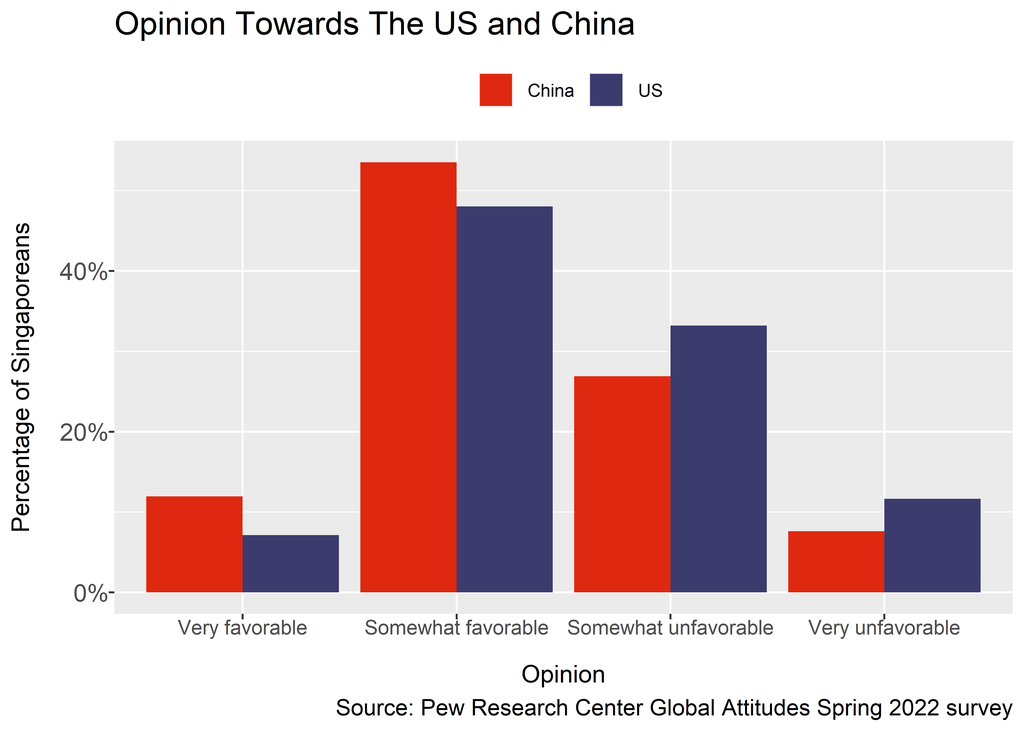

```r
# Fig 1 :  opinion towards US and China

p_opinion <- ggplot(plot_data, aes(x = Response, fill = Question)) +
  geom_bar(position = "dodge",mapping = aes(y = after_stat(prop), group = Question)) +
  scale_y_continuous(labels = scales::percent) +
  scale_fill_manual(values=c("#de2910","#3C3B6E"), breaks = c("fav_china","fav_us"),
                    labels = c("fav_china" = "China", "fav_us" = "US")) +
  labs(x = "Opinion", y = "Percentage of Singaporeans",
       title = "Opinion Towards The US and China",
       caption = "Source: Pew Research Center Global Attitudes Spring 2022 survey",
       fill=NULL)+
  theme(title = element_text(size=14),
        axis.text.x = element_text(size = 10,margin = margin(b = 10)),
        axis.text.y = element_text(size = 12,margin = margin(l = 10)),
        axis.title = element_text(size = 12),
        plot.title = element_text(size = 16, margin = margin(b = 10)),
        legend.position ="top")

p_opinion
```

In the Global Attitudes Spring 2022 survey, 1001 Singaporeans were asked about their opinion towards China and the US. Interestingly, the percentage of respondents from Singapore who indicated that they have a favourable view of China surpased those who have a favourable view of the US. More than 11% of respondents who answered the survey had a very favourable opinion of China and over 53% of them had a somewhat favourable opinion of China. Their opinion towards the US was lower at 7% and 47% for very favourable and somewhat favourable respectively. More than 10% of respondents also had a very unfavourable view of the US compared to less than 10% for China. Although the majority view both the US and China somewhat favourably, it seems like some Singaporeans are now viewing the US less favourably compared to China. To delve into the reasons behind these choices, this report will first look into the demographics of the survey respondents and how this may have affected their views on the US and China. Several factors including the age, gender, ethnicity level of education and income range will be examined. The survey was answered by a diverse age group ranging from 18 year old youths to the elderly in their eighties. The age group of respondents who had a very favourable view of China show a bimodal distribution whereby those in their thirties and fifities were more likely to be found selecting very favourable when asked about their opinion on China (Fig 2).

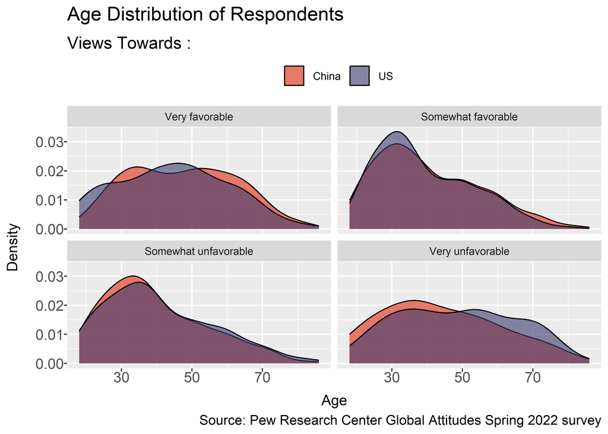

```r
ggsave("Fig1_Opinion Towards The US and China.png",plot = p_opinion)

# Looking into the demographics of the people who have a favourable view towards China (demo1 to demo4)

# Vector created to label all the facet plots
facet_names <- c(fav_china = "China",fav_us = "US")


# Fig 2 : Age distribution of respondents
p_demo2 <- ggplot(plot_data, aes(x= age,fill=Question)) +
  facet_wrap(~Response) +
  geom_density(alpha = 0.6) +
  scale_fill_manual(values=c("#de2910","#3C3B6E"), breaks = c("fav_china","fav_us"),
                    labels = c("fav_china" = "China", "fav_us" = "US")) +
  labs(x = "Age", y = "Density",
       title = "Age Distribution of Respondents",
       subtitle = "Views Towards : ",
       caption = "Source: Pew Research Center Global Attitudes Spring 2022 survey",fill=NULL) +
  theme(title = element_text(size=14),
        axis.text.x = element_text(size = 12,margin = margin(b = 5)),
        axis.text.y = element_text(size = 12,margin = margin(l = 10)),
        axis.title = element_text(size = 12),
        plot.title = element_text(size = 16, margin = margin(b = 10)),
        legend.position ="top")

p_demo2
```

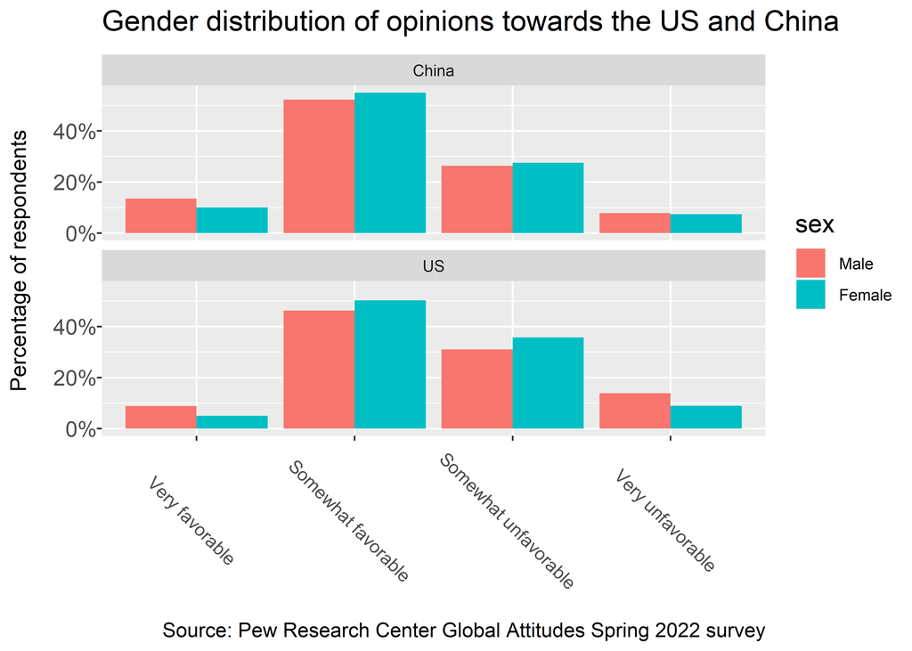

```r
# Fig 3 : Gender distribution of respondents
p_demo3 <- ggplot(plot_data, aes(x= Response,fill=sex)) +
  geom_bar(position="dodge",mapping = aes(y = after_stat(prop),group = sex)) +
  scale_y_continuous(labels = scales::percent) +
  facet_wrap(~Question,ncol=1,labeller = as_labeller(facet_names)) +
  labs(x = "", y = "Percentage of respondents",
       title = "Gender distribution of opinions towards the US and China",
       caption = "Source: Pew Research Center Global Attitudes Spring 2022 survey") +
  theme(title = element_text(size=14),
        axis.text.y = element_text(size = 12,margin = margin(l = 10)),
        axis.text.x = element_text(size = 10,angle =-45),
        axis.title = element_text(size = 12),
        plot.title = element_text(size = 16, margin = margin(b = 10)))

p_demo3
```

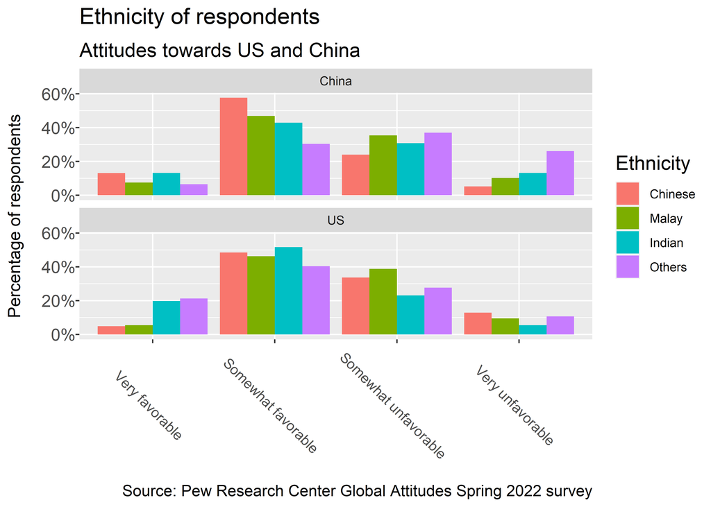

```r
# Fig 4 : Ethnicity of respondents

p_demo4 <- ggplot(plot_data, aes(x= Response,fill=d_identity_singapore)) +
  geom_bar(position="dodge",mapping = aes(y = after_stat(prop),group = d_identity_singapore)) +
  facet_wrap(~Question,ncol=1,labeller = as_labeller(facet_names)) +
  scale_y_continuous(labels = scales::percent) +
  scale_fill_discrete (labels=c ('Chinese', 'Malay','Indian','Others')) +
  labs(x = "", y = "Percentage of respondents",
       title = "Ethnicity of respondents",
       caption = "Source: Pew Research Center Global Attitudes Spring 2022 survey",
       subtitle = "Attitudes towards US and China",
       fill = "Ethnicity" ) +
  theme(title = element_text(size=14),
        axis.text.y = element_text(size = 12,margin = margin(l = 10)),
        axis.text.x = element_text(size = 10,angle =-45),
        axis.title = element_text(size = 12),
        plot.title = element_text(size = 16, margin = margin(b = 10)))
p_demo4
```

In terms of ethnicity, almost 60% of those who identify as ethnically chinese have a somewhat favourable view of China. Although this due to their shared heritage, almost 50% of the Chinese respondents also had a somewhat favourable view of the US. The proportion of Chinese and Indian Singaporeans who had a very favourable view of China were also very similar. On the other hand, those who did not identify as Chinese, Malay or Indian had a much higher proportion of very unfavourable responses when asked about China compared to the other races. This is in contrast to their much higher proportion indicating that they have a very favourable view of the US. Overall, some respondents do lean towards countries that share the same heritage as themselves but the majority do not favour one country over the other.

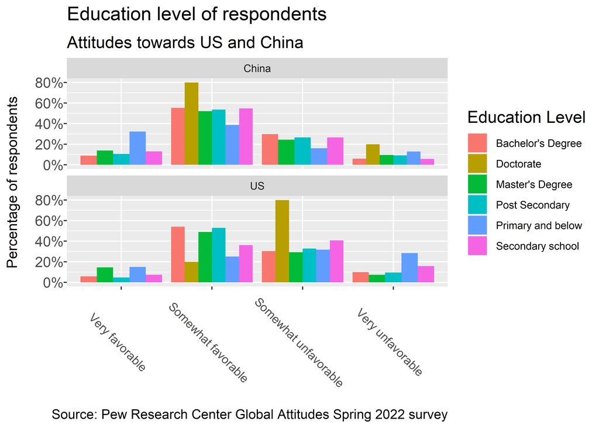

```r
lookup_df <- data.frame(
  key = 1:10,
  d_educ_singapore = unique(plot_data$d_educ_singapore))

lookup_df %>%
  mutate(edu_level = case_when(key %in% c(2,7) ~ "Primary and below",
                               key %in% c(5,6) ~ "Secondary school",
                               key %in% c(1,8) ~ "Post Secondary",
                               key == 3 ~ "Bachelor's Degree",
                               key == 4 ~ "Master's Degree",
                               key == 10 ~ "Doctorate",
                               key == 9 ~ ""
        )) -> lookup_df

plot_data %>% left_join(y = lookup_df,by = "d_educ_singapore") -> plot_data

# Fig 5 : Education level of respondents
p_edu_level <- ggplot(subset(plot_data,!d_educ_singapore == "Refused (DO NOT READ)"),aes(x= Response,fill = edu_level)) +
  geom_bar(position="dodge",mapping = aes(y = after_stat(prop),group = edu_level)) +
  scale_y_continuous(labels = scales::percent) +
  facet_wrap(~Question,ncol =1, labeller = as_labeller(facet_names)) + theme(legend.position = "right") +
  labs(x = "", y = "Percentage of respondents",
       title = "Education level of respondents",
       subtitle = "Attitudes towards US and China",
       caption = "Source: Pew Research Center Global Attitudes Spring 2022 survey",
       fill = "Education Level" ) +
  theme(title = element_text(size=14),
        axis.text.y = element_text(size = 12,margin = margin(l = 10)),
        axis.text.x = element_text(size = 10,angle =-45),
        axis.title = element_text(size = 12),
        plot.title = element_text(size = 16, margin = margin(b = 10)))

p_edu_level
```

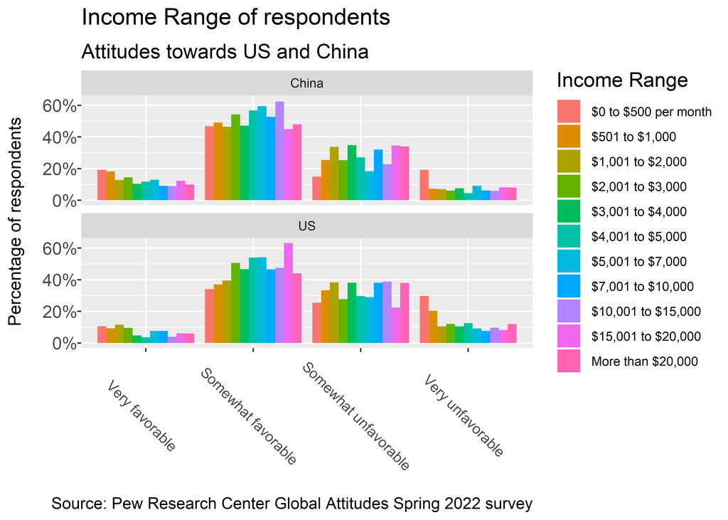

```r
# Fig 6 : Income Range of respondents

p_income_level <- ggplot(subset(plot_data,!d_income_singapore %in% c("99","98")),aes(x= Response,fill = d_income_singapore)) +
  geom_bar(position="dodge",mapping = aes(y = after_stat(prop),group = d_income_singapore)) +
  scale_y_continuous(labels = scales::percent) +
  facet_wrap(~Question,ncol =1, labeller = as_labeller(facet_names))+
  labs(x = "", y = "Percentage of respondents",
       title = "Income Range of respondents",
       subtitle = "Attitudes towards US and China",
       caption = "Source: Pew Research Center Global Attitudes Spring 2022 survey",
       fill = "Income Range" ) +
  theme(title = element_text(size=14),
        axis.text.y = element_text(size = 12,margin = margin(l = 10)),
        axis.text.x = element_text(size = 10,angle =-45),
        axis.title = element_text(size = 12),
        plot.title = element_text(size = 16, margin = margin(b = 10)))

p_income_level
```

Lastly, the income levels of the respondents may also play a role in their responses. Higher proportions of those from lower income groups were observed to have selected options on both extremes for each country when compared to higher income groups.